# Predicting IMDB Ratings

Ryan Heslin

2021-03-31

The data here concern about 80,000 movies on www.imdb.com. I’m interested in predicting the number of user reviews a movie receives. Several features, such as year of release, language, and genre seem promising. Unfortunately, the data are ridden with NA’s I can’t reasonably impute.

# EDA and Processing

```r
library(tidyverse)
library(tidymodels)
knitr::opts_chunk$set(comment =  "", fig.pos = "center")

ratings_raw <- read_csv("../data/imdb/IMDb movies.csv")
head(ratings_raw)
```

```
## # A tibble: 6 x 22
##   imdb_title_id title  original_title   year date_published genre duration country language director writer production_comp~ actors  description  avg_vote votes budget usa_gross_income
##   <chr>         <chr>  <chr>           <dbl> <chr>          <chr>    <dbl> <chr>   <chr>    <chr>    <chr>  <chr>            <chr>   <chr>           <dbl> <dbl> <chr>  <chr>
## 1 tt0000009     Miss ~ Miss Jerry       1894 1894-10-09     Roma~       45 USA     None     Alexand~ Alexa~ Alexander Black~ Blanch~ The adventu~      5.9   154 <NA>   <NA>
## 2 tt0000574     The S~ The Story of t~  1906 1906-12-26     Biog~       70 Austra~ None     Charles~ Charl~ J. and N. Tait   Elizab~ True story ~      6.1   589 $ 2250 <NA>
## 3 tt0001892     Den s~ Den sorte drøm   1911 1911-08-19     Drama       53 German~ <NA>     Urban G~ Urban~ Fotorama         Asta N~ Two men of ~      5.8   188 <NA>   <NA>
## 4 tt0002101     Cleop~ Cleopatra        1912 1912-11-13     Dram~      100 USA     English  Charles~ Victo~ Helen Gardner P~ Helen ~ The fabled ~      5.2   446 $ 450~ <NA>
## 5 tt0002130     L'Inf~ L'Inferno        1911 1911-03-06     Adve~       68 Italy   Italian  Frances~ Dante~ Milano Film      Salvat~ Loosely ada~      7    2237 <NA>   <NA>
## 6 tt0002199     From ~ From the Mange~  1912 1913           Biog~       60 USA     English  Sidney ~ Gene ~ Kalem Company    R. Hen~ An account ~      5.7   484 <NA>   <NA>
## # ... with 4 more variables: worlwide_gross_income <chr>, metascore <dbl>, reviews_from_users <dbl>, reviews_from_critics <dbl>
```

My custom `ggplot` theme.

```r
my_theme <- function()
{
    theme_standard <- ggplot2::theme(panel.background = element_blank(),
        panel.border = element_rect(color = "black", fill = NA),
        panel.grid = element_blank(), panel.grid.major.x = element_line(color = "gray93"),
        legend.background = element_rect(fill = "gray93"),
        plot.title = element_text(size = 15, family = "sans",
            face = "bold", vjust = 1.3), plot.title.position = "plot",
        plot.subtitle = element_text(size = 10, family = "sans"),
        legend.title = element_text(size = 10, family = "sans",
            face = "bold"), axis.title = element_text(size = 9,
            family = "sans", face = "bold"), axis.text = element_text(size = 8,
            family = "sans"), strip.background = element_rect(color = "black",
            fill = "black"), strip.text.x = element_text(color = "white"),
        strip.text.y = element_text(color = "white"))
    ggplot2::theme_set(theme_standard)
}
my_theme()
```

One problem crops up immediately: many movie budgets are given in units of foreign currency. Simply converting to numeric would give misleading values. I decide to just NA them for now.

```r
ratings_raw %>% filter(if_any(c(budget, ends_with("income")), ~str_detect(.x, "^[^[$\\d]]") & !is.na(.x)))
```

```
# A tibble: 7,174 x 22
   imdb_title_id title  original_title   year date_published genre duration country language director writer production_comp~ actors  description avg_vote votes budget usa_gross_income
   <chr>         <chr>  <chr>           <dbl> <chr>          <chr>    <dbl> <chr>   <chr>    <chr>    <chr>  <chr>            <chr>   <chr>          <dbl> <dbl> <chr>  <chr>
 1 tt0002445     Quo V~ Quo Vadis?       1913 1913-03-01     Dram~      120 Italy   Italian  Enrico ~ Henry~ Società Italian~ Amleto~ "An epic I~      6.2   273 ITL 4~ <NA>
 2 tt0002452     Indep~ Independenta R~  1912 1912-09-01     Hist~      120 Romania <NA>     Aristid~ Arist~ Societatea Film~ Aristi~ "The movie~      6.7   198 ROL 4~ <NA>
 3 tt0008663     Terje~ Terje Vigen      1917 1917-01-29     Dram~       48 Sweden  <NA>     Victor ~ Henri~ Svenska Biograf~ Victor~ "Terje Vig~      7.4  1508 SEK 6~ <NA>
 4 tt0008879     I pro~ Berg-Ejvind oc~  1918 1919           Drama      136 Sweden  <NA>     Victor ~ Victo~ Svenska Biograf~ Victor~ "A strange~      7.3  1518 SEK 1~ <NA>
 5 tt0010755     Il ca~ Sången om den ~  1919 1919-04-14     Dram~      145 Sweden  <NA>     Mauritz~ Tom B~ Svenska Biograf~ Lars H~ "Olof Kosk~      6.9   157 SEK 1~ <NA>
 6 tt0010969     L'atl~ L'Atlantide      1921 1921-05-28     Adve~      136 France~ French   Jacques~ Pierr~ International e~ Jean A~ "Two men, ~      6.7   315 FRF 1~ <NA>
 7 tt0011440     Marke~ Markens grøde    1921 1921-12-02     Drama      107 Norway  <NA>     Gunnar ~ Knut ~ Christiana Film  Amund ~ "After the~      6.6   195 NOK 2~ <NA>
 8 tt0012134     Eldor~ Eldorado         1921 1921-10-28     Drama      100 France  French   Marcel ~ Marce~ Gaumont Série P~ Ève Fr~ "Sibilla i~      7     362 FRF 2~ <NA>
 9 tt0014925     La za~ Forbidden Para~  1924 1924-11-30     Come~       69 USA     <NA>     Ernst L~ Lajos~ Famous Players-~ Pola N~ "Alexei sa~      6.1   125 <NA>   EUR 252076
10 tt0015014     Futur~ L'inhumaine      1924 1924-12-12     Adve~      135 France  French   Marcel ~ Pierr~ Cinégraphic      Jaque ~ "Claire Le~      7.2   712 FRF 2~ <NA>
# ... with 7,164 more rows, and 4 more variables: worlwide_gross_income <chr>, metascore <dbl>, reviews_from_users <dbl>, reviews_from_critics <dbl>
```

```r
ratings <- select(ratings_raw, -2) %>%
  rename(title = "original_title") %>%
  mutate(across(c(budget, ends_with("income")), ~ if_else(str_detect(.x, "^[^[$\\d]]"), NA_character_, str_remove(.x, "^\\$")) %>% as.numeric())) %>%
   replace_na(list(reviews_from_critics = 0))
```

Several variables with multiple values, such as genre, are given as comma- separated strings. I define a function to unchop them.

```r
separate_rows2 <- function(df, sep = "[^[:alnum:].]+", ...){
  cols = rlang::ensyms(...)
  purrr::reduce(cols, ~separate_rows(.x, !!.y, sep = sep), .init = df)
}
ratings_unchopped <- ratings %>%
  separate_rows2(sep = "[,]\\s", country, genre, language)
```

Metascore is a promising predictor, but is missing for most observations. Only 6058 do not have at least one NA.

I don’t think any can be reasonably imputed, since in most cases the value is truly nonexistent (e.g., a movie with no metascore).

```r
colSums(is.na(ratings))
```

```
        imdb_title_id                 title                  year        date_published                 genre              duration               country              language
                    0                     0                     1                     0                     0                     0                    64                   833
             director                writer    production_company                actors           description              avg_vote                 votes                budget
                   87                  1572                  4455                    69                  2115                     0                     0                 69253
     usa_gross_income worlwide_gross_income             metascore    reviews_from_users  reviews_from_critics
                70534                 54900                 72550                  7597                     0
```

## Reponse

Some elementary EDA. User reviews has extreme positive skew, with a handful of movies with very many reviews.

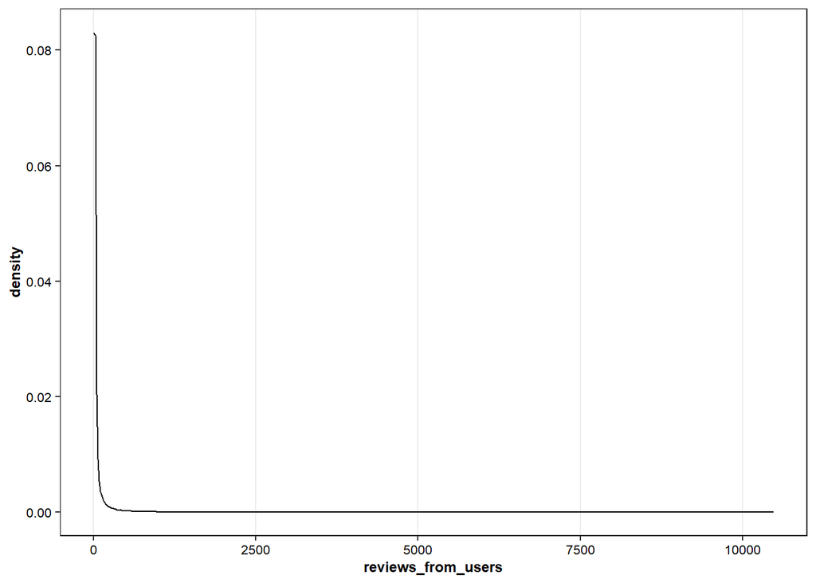

```r
ratings %>% ggplot(aes(x =reviews_from_users)) +
  geom_density()
```

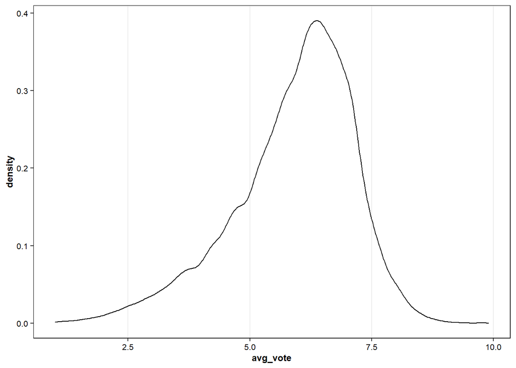

```r
ratings %>% ggplot(aes(x = avg_vote)) +
  geom_density()
```

```r
ratings %>% slice_max(n = 25, order_by = reviews_from_users) %>%
  select(title, worlwide_gross_income, genre, reviews_from_users)
```

```
# A tibble: 25 x 4
   title                                             worlwide_gross_income genre                      reviews_from_users
   <chr>                                                             <dbl> <chr>                                   <dbl>
 1 Joker                                                        1074251311 Crime, Drama, Thriller                  10472
 2 Avengers: Endgame                                            2797800564 Action, Adventure, Drama                 8869
 3 The Shawshank Redemption                                       28815245 Drama                                    8232
 4 Dil Bechara                                                       42248 Comedy, Drama, Romance                   7639
 5 Star Wars: Episode IX - The Rise of Skywalker                1074144248 Action, Adventure, Fantasy               7553
 6 Captain Marvel                                               1128276090 Action, Adventure, Sci-Fi                7207
 7 The Dark Knight                                              1005455211 Action, Crime, Drama                     6938
 8 Star Wars: Episode VIII - The Last Jedi                      1332540187 Action, Adventure, Fantasy               6718
 9 The Lord of the Rings: The Fellowship of the Ring             887934303 Action, Adventure, Drama                 5392
10 Mrs. Serial Killer                                                   NA Crime, Drama, Thriller                   5261
# ... with 15 more rows
```

## Metascore

The correlation between metascore and mean rating is consistent across genres.

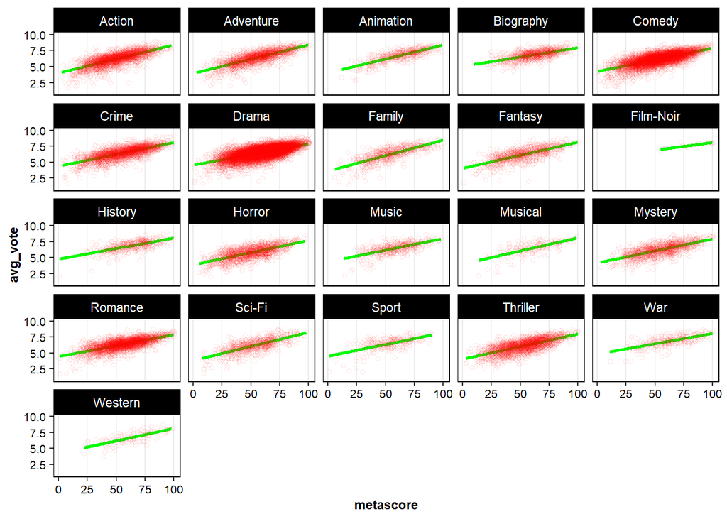

```r
no_meta_genres <- c("Adult", "Documentary", "News", "Reality", "Reality-TV",
                    "TV" )
ratings %>%
  separate_rows(sep = "[,]\\s", genre) %>%
  filter(!genre %in% no_meta_genres) %>%
  ggplot(aes(x = metascore, y = avg_vote)) +
  geom_smooth(method = "lm", col = "green") +
  geom_jitter(alpha = .1, color = "red", stroke = .1, shape = 21) +
  facet_wrap(genre ~ .)
```

There is still pronounced positive skew even after logging. A few genres have only a handful of instances.

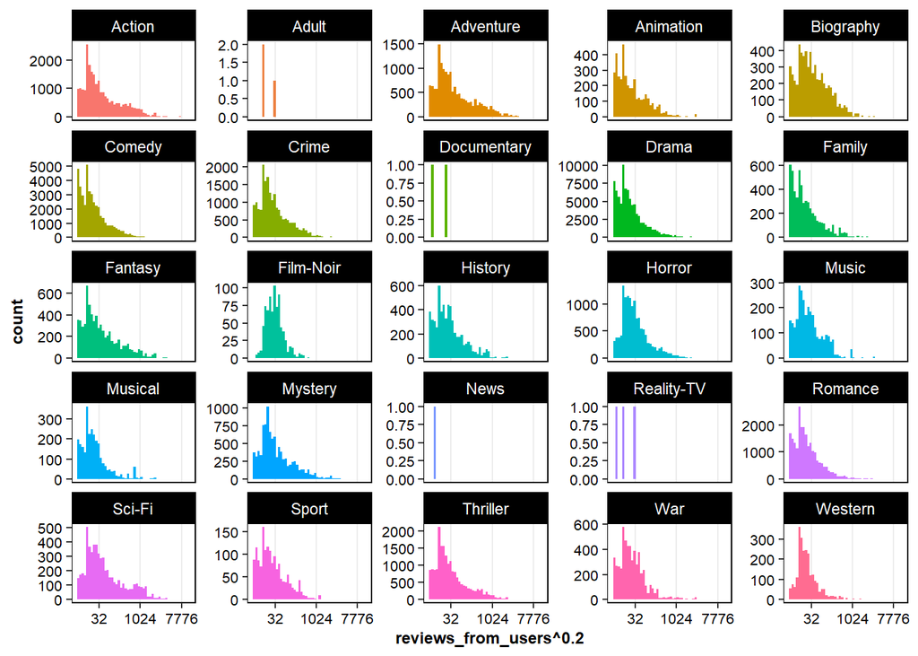

```r
ratings_unchopped %>%
  ggplot(aes(x =  reviews_from_users^.2, fill = genre)) +
  geom_histogram(show.legend = FALSE, bins = 50) +
  scale_x_continuous(labels = function(x) x^5)+
  facet_wrap(. ~ genre, scales = "free_y")
```

## Country and Language

Unsurprisingly, the most reviews for each genre go to US and English-language movies.

```r
by_genre <- ratings_unchopped %>% group_by(genre) %>%
  distinct(title, .keep_all = TRUE) %>%
  slice_max(n=10, order_by = reviews_from_users) %>%
  ungroup()

head(by_genre)
```

```
# A tibble: 6 x 21
  imdb_title_id title   year date_published genre duration country language director writer production_comp~ actors description avg_vote  votes budget usa_gross_income worlwide_gross_~
  <chr>         <chr>  <dbl> <chr>          <chr>    <dbl> <chr>   <chr>    <chr>    <chr>  <chr>            <chr>  <chr>          <dbl>  <dbl>  <dbl>            <dbl>            <dbl>
1 tt4154796     Aveng~  2019 2019-04-24     Acti~      181 USA     English  Anthony~ Chris~ Marvel Studios   Rober~ After the ~      8.4 7.55e5 3.56e8        858373000       2797800564
2 tt2527338     Star ~  2019 2019-12-18     Acti~      141 USA     English  J.J. Ab~ Chris~ Walt Disney Pic~ Carri~ The surviv~      6.6 3.47e5 2.75e8        515202542       1074144248
3 tt4154664     Capta~  2019 2019-03-06     Acti~      123 USA     English  Anna Bo~ Anna ~ Walt Disney Pic~ Brie ~ Carol Danv~      6.9 4.23e5 1.60e8        426829839       1128276090
4 tt0468569     The D~  2008 2008-07-23     Acti~      152 USA     English  Christo~ Jonat~ Warner Bros.     Chris~ When the m~      9   2.24e6 1.85e8        535234033       1005455211
5 tt2527336     Star ~  2017 2017-12-13     Acti~      152 USA     English  Rian Jo~ Rian ~ Walt Disney Pic~ Mark ~ Rey develo~      7   5.48e5 3.17e8        620181382       1332540187
6 tt0120737     The L~  2001 2002-01-18     Acti~      178 New Ze~ English  Peter J~ J.R.R~ New Line Cinema  Alan ~ A meek Hob~      8.8 1.62e6 9.30e7        315544750        887934303
# ... with 3 more variables: metascore <dbl>, reviews_from_users <dbl>, reviews_from_critics <dbl>
```

```r
fct_count(by_genre$language, sort = TRUE)
```

```
# A tibble: 8 x 2
  f            n
  <fct>    <int>
1 English    198
2 Hindi        9
3 Italian      3
4 French       2
5 Korean       2
6 Spanish      2
7 Japanese     1
8 <NA>         1
```

```r
fct_count(by_genre$country, sort = TRUE)
```

```
# A tibble: 16 x 2
   f               n
   <fct>       <int>
 1 USA           163
 2 UK             21
 3 India           9
 4 Australia       4
 5 Italy           3
 6 New Zealand     3
 7 Canada          2
 8 China           2
 9 Denmark         2
10 France          2
11 South Korea     2
12 Chile           1
13 Germany         1
14 Japan           1
15 Mexico          1
16 <NA>            1
```

## Director

The directors with the highest sums of average rating worked mostly in Golden Age Hollywood - makes sense, as they made many well-received movies.

```r
ratings %>% count(director, wt = avg_vote) %>%
arrange(-n)
```

```
# A tibble: 34,734 x 2
   director             n
   <chr>            <dbl>
 1 Michael Curtiz    556.
 2 <NA>              536.
 3 Lesley Selander   485.
 4 Lloyd Bacon       455
 5 John Ford         450.
 6 Richard Thorpe    426.
 7 Jesús Franco      410.
 8 William Beaudine  410.
 9 Raoul Walsh       402
10 Gordon Douglas    395.
# ... with 34,724 more rows
```

US and English-language movies are not surprisingly predominant.

```r
aggs <- ratings %>% select(title, country, genre, language) %>%
  separate_rows2(sep = "[,]\\s", country, genre) %>%
  select(-title) %>%
  map(table, exclude = list(NA)) %>%
  map(sort, decreasing = TRUE)

map(aggs, head)
```

```
$country

   USA     UK France  India  Italy  Japan
 75840  16280  15963  13597   9392   8054

$genre

   Drama   Comedy  Romance   Action Thriller    Crime
   62339    35055    17382    16576    14548    13979

$language

 English   French  Spanish  Italian Japanese    Hindi
   92687     9832     6977     6358     6154     5071
```

## Number of Votes and Critic Reviews

reviews_from_users unsurprisingly has strong correlations with number of votes. and number of critic’s reviews. Metascore, interestingly, has almost no correlation.

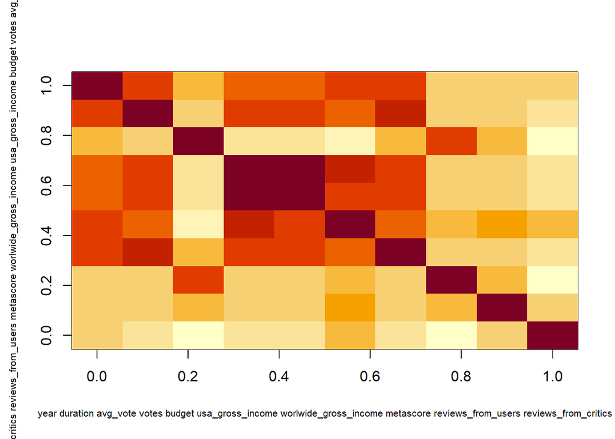

```r
ratings %>% select(where(is.numeric)) %>%
  cor(use = "pairwise.complete.obs") %>%
  apply(MARGIN = 1, rev) %>%
  {
    image(
      z = .,
      xlab = paste(dimnames(.)[[2]], collapse = " "),
      ylab = paste(dimnames(.)[[1]], collapse = " "),
      cex.lab = .65
    )
  }
```

Interestingly, the movies with the highest ratios of user to critic reviews mostly come from India. IMDB probably undersamples reviews in the foreign-language press, but Indian users are under no such restriction.

```r
ratings %>% filter(reviews_from_critics >0) %>%
  arrange(-(reviews_from_users / reviews_from_critics))
```

```
# A tibble: 74,058 x 21
   imdb_title_id title  year date_published genre duration country language director writer production_comp~ actors description avg_vote  votes budget usa_gross_income worlwide_gross_~
   <chr>         <chr> <dbl> <chr>          <chr>    <dbl> <chr>   <chr>    <chr>    <chr>  <chr>            <chr>  <chr>          <dbl>  <dbl>  <dbl>            <dbl>            <dbl>
 1 tt7743400     Jhal~  2019 2019-11-14     Drama      104 India   Hindi    Brahman~ Tanvi~ Mobius Films     Boman~ "In a twin~      8.8   1131     NA               NA             8488
 2 tt2073600     Lad:~  2013 2017-04-05     Drama       96 UK      English  Dan Har~ Dan H~ <NA>             Brett~ "A teenage~      7.9   1874 160000               NA               NA
 3 tt11730940    Bamf~  2020 2020-04-10     Roma~      102 India   Hindi    Ranjan ~ Ranja~ Jar Pictures     Adity~ "A passion~      7.4   1522     NA               NA               NA
 4 tt11134856    Chha~  2019 2019-10-18     Drama       90 India   Hindi    Sameer ~ Samee~ Saregama India   Siddh~ "Chappad P~      6.3    732     NA               NA               NA
 5 tt10230426    Mrs.~  2020 2020-05-01     Crim~      106 India   Hindi, ~ Shirish~ Shiri~ Three's Company~ Jacqu~ "When a do~      4.9  10943     NA               NA               NA
 6 tt8110330     Dil ~  2020 2020-07-24     Come~      101 India   Hindi    Mukesh ~ Shash~ Fox STAR Studios Susha~ "The emoti~      8.8 101686     NA               NA            42248
 7 tt4172402     Auda~  2015 2015-06-24     Drama       55 USA     English  Eddie R~ Ray C~ Living Waters P~ Travi~ "\"Audacit~      3.9   4293     NA               NA               NA
 8 tt6642396     Jatt~  2017 2017-05-19     Come~      139 India   Hindi    Honeypr~ Gurme~ Hakikat Enterta~ Amard~ "A teacher~      5.9   3325     NA               NA            13533
 9 tt5944812     Dead~  2017 2017-09-13     Adve~      120 Austra~ English  Michal ~ Micha~ Morning Starr P~ Justi~ "Dead Sunr~      4.1   1168     NA               NA               NA
10 tt1340778     I Am~  2010 2012-08-31     Come~      118 India   Hindi    Saurabh~ <NA>   Planman Motion ~ Rajat~ "The perks~      6.1   1169     NA               NA               NA
# ... with 74,048 more rows, and 3 more variables: metascore <dbl>, reviews_from_users <dbl>, reviews_from_critics <dbl>
```

## Gross

Budget and domestic and foreign gross all have decent correlations with number of reviews, which makes sense.

```r
ratings  %>%
  select(where(is.numeric)) %>% cor(use = "pairwise.complete.obs")
```

```
                              year  duration   avg_vote      votes     budget usa_gross_income worlwide_gross_income   metascore reviews_from_users reviews_from_critics
year                   1.000000000 0.1728071 -0.2175732 0.05855566  0.2001273       0.07085618           0.005898698 -0.18320938         0.07061812            0.1273023
duration               0.172807106 1.0000000  0.2424325 0.12561842  0.3013007       0.16034784           0.138693348  0.21053134         0.13083622            0.1087806
avg_vote              -0.217573179 0.2424325  1.0000000 0.16697156  0.1917110       0.16574888           0.140743670  0.69133816         0.13818480            0.1803771
votes                  0.058555661 0.1256184  0.1669716 1.00000000  0.5369289       0.67245412           0.661670549  0.19473004         0.76623660            0.6717611
budget                 0.200127277 0.3013007  0.1917110 0.53692887  1.0000000       0.69157003           0.751953153 -0.01875270         0.56489594            0.6211405
usa_gross_income       0.070856183 0.1603478  0.1657489 0.67245412  0.6915700       1.00000000           0.932302516  0.06703562         0.65255086            0.5643152
worlwide_gross_income  0.005898698 0.1386933  0.1407437 0.66167055  0.7519532       0.93230252           1.000000000  0.06516894         0.64420974            0.5762613
metascore             -0.183209380 0.2105313  0.6913382 0.19473004 -0.0187527       0.06703562           0.065168941  1.00000000         0.12613147            0.2364335
reviews_from_users     0.070618118 0.1308362  0.1381848 0.76623660  0.5648959       0.65255086           0.644209741  0.12613147         1.00000000            0.6736382
reviews_from_critics   0.127302255 0.1087806  0.1803771 0.67176111  0.6211405       0.56431523           0.576261283  0.23643355         0.67363821            1.0000000
```

More recent movies naturally have far more reviews, with what looks like a big jump around the start of the 1990s, when the current generation of Internet users was born. the median number of reviews, however, is more consistent, suggesting some recent outliers.

```r
by_year <- ratings %>% group_by(year) %>%
  summarize(across(reviews_from_users, .fns = map(list(mean = mean, median = median, sd = sd, sum = sum), ~partial(.x, na.rm = TRUE))))
tail(by_year, n = 10)
```

```
# A tibble: 10 x 5
    year reviews_from_users_mean reviews_from_users_median reviews_from_users_sd reviews_from_users_sum
   <dbl>                   <dbl>                     <dbl>                 <dbl>                  <dbl>
 1  2012                    41.4                         7                  151.                  92547
 2  2013                    43.2                         7                  141.                 106126
 3  2014                    43.9                         7                  156.                 111732
 4  2015                    39.7                         7                  153.                 101495
 5  2016                    42.2                         7                  152.                 114537
 6  2017                    49.6                         8                  208.                 146792
 7  2018                    72.1                        11                  261.                 212009
 8  2019                    98.3                        12                  446.                 250446
 9  2020                   112.                         18                  443.                  81937
10    NA                   135                         135                   NA                     135
```

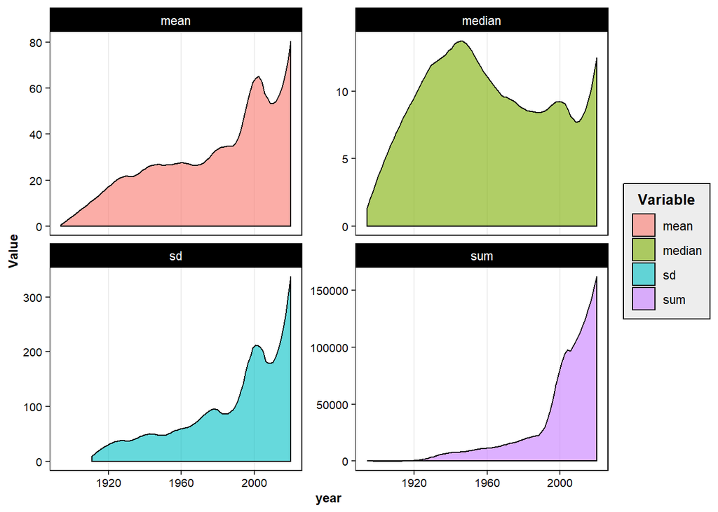

```r
by_year %>% pivot_longer(cols = -year, names_to = "Variable", values_to = "Value") %>%
  mutate(Variable = str_extract(Variable,"([^_]+)$")) %>%
  ggplot(aes(x = year, y = Value, fill = Variable)) +
  stat_smooth(geom = "area", method = "loess", span = .3, alpha = .6, outline.type = "full" , position = position_stack(), col = "black") +
  facet_wrap(. ~ Variable, scales = "free_y")
```

Hilariously, the language with the highest average rating is Quenya, one of the two elven languages in *Lord of the Rings*. Sindarin’s not far behind.

This illustrates the general pattern: the highest average ratings correspond to small countries and obscure languages because those correspond to only a few films with small but devoted fanbases. English is only about 5.72, by contrast.

```r
ratings_unchopped %>%
  {
    map2(
      replicate(3, ., simplify = FALSE),
      alist(genre, country, language),
      ~ group_by(.x, !!.y)
    )
  } %>%
  map( ~ summarize(.x, across(
    c(avg_vote, metascore, reviews_from_users, reviews_from_critics),
    mean,
    na.rm = TRUE
  ))) %>%
  map( ~ arrange(.x, -avg_vote))
```

```
[[1]]
# A tibble: 25 x 5
   genre       avg_vote metascore reviews_from_users reviews_from_critics
   <chr>          <dbl>     <dbl>              <dbl>                <dbl>
 1 Documentary     7.3      NaN                  9                   11.5
 2 Biography       6.72      63.0              108.                  73.5
 3 Film-Noir       6.68      86.5               47.8                 24.6
 4 War             6.64      65.0               68.1                 32.6
 5 History         6.63      63.8               83.8                 49.5
 6 Music           6.45      61.6               69.1                 44.0
 7 News            6.4      NaN                  3                    3
 8 Drama           6.36      61.8               65.7                 38.3
 9 Musical         6.30      62.5               59.5                 18.9
10 Animation       6.28      61.6               74.1                 43.8
# ... with 15 more rows

[[2]]
# A tibble: 195 x 5
   country                       avg_vote metascore reviews_from_users reviews_from_critics
   <chr>                            <dbl>     <dbl>              <dbl>                <dbl>
 1 Libya                             8.32     NaN               101.                  24.6
 2 Malawi                            7.6       68               157                   46
 3 Moldova                           7.56     NaN                 1.81                 3.33
 4 Uganda                            7.48     NaN                77.7                 12.2
 5 Kuwait                            7.32      73                61.4                 21.1
 6 Soviet Union                      7.20      90                13.5                  5.41
 7 Sri Lanka                         7.19      70                 7.76                 2.90
 8 Botswana                          7.17      73               118                   33
 9 Bhutan                            7.11      64.2              17.5                 29.5
10 Holy See (Vatican City State)     7.1      NaN                 2                    2
# ... with 185 more rows

[[3]]
# A tibble: 268 x 5
   language    avg_vote metascore reviews_from_users reviews_from_critics
   <chr>          <dbl>     <dbl>              <dbl>                <dbl>
 1 Quenya          8.9       94               3718                  353
 2 Himachali       8.7      NaN                  6                    0
 3 Maithili        8.1      NaN                  3                    6
 4 Pawnee          8         74.4             1160.                 433.
 5 Mende           7.82      63.8              607.                 156.
 6 Old English     7.77      75.4             1983.                 300.
 7 Sindarin        7.76      91               2437.                 227.
 8 Hmong           7.7       78.5              508                  208
 9 Abkhazian       7.61     NaN                 10.3                 55.3
10 Minangkabau     7.6      NaN                 10                    2
# ... with 258 more rows
```

This section reflects an abandoned attempt to compute individual genre means. I ended up finding a different approach.

I clean up the data, dropping NA’s and log-trainsforming.

```r
ratings_cleaned <-
  ratings %>% filter(if_all(
    c(language,
      genre,
      worlwide_gross_income,
      reviews_from_critics,
      reviews_from_users,
      year),
    ~ !is.na(.)
  )) %>%
  mutate(reviews_from_users = log10(reviews_from_users))
```

I compute genre-specific means by taking the difference of the overall mean and the mean of all movies in that genre (in log units). I will add these centered means diretcly to the predicted values.

```r
genres <- unique(ratings_unchopped$genre)  %>%
  setdiff(no_meta_genres)

mu <- ratings_cleaned %>%
  pull(reviews_from_users) %>%
  mean()

means <- ratings_cleaned %>%
  separate_rows(genre, sep = "[,]\\s") %>%
  filter(!genre %in% no_meta_genres) %>%
  group_by(genre) %>%
  summarize(genre_mean = mean(reviews_from_users, na.rm = TRUE), .groups = "drop") %>%
  {setNames(.$genre_mean, .$genre)}

means <- means  - mu

adj_means <- ratings_cleaned %>%
  separate_rows(genre, sep = "[,]\\s") %>%
  mutate(!!!setNames(as.list(rep(0, length(genres))), nm = genres),
                             across(genres, ~if_else(genre == cur_column(), means[[cur_column()]], 0))) %>%
  group_by(imdb_title_id) %>%
  summarize(imdb_title_id =unique(imdb_title_id), across(genres, sum))
```

I condense langauge into a binary “English/Other” factor, since that seems the most important pattern.

```r
ratings_cleaned <- ratings_cleaned %>% mutate(language = factor(if_else(str_detect(language, "^English"), "English", "Other"))) %>%
  left_join(., adj_means %>% select(imdb_title_id, matches("^[A-Z]", ignore.case = FALSE)), by = "imdb_title_id")
```

I remove NA’s and partition the data.

```r
set.seed(1996)

inds <-
  sample(1:nrow(ratings_cleaned), nrow(ratings_cleaned)  %/% 5)
ratings_train <- ratings_cleaned[inds,]
ratings_test <- ratings_cleaned[-inds,]
```

# Modeling

I create the recipe.

```r
dummies <- ratings_train %>%
  select(genres) %>%
  rowSums()

lm_rec <-
  recipe(
    formula = reviews_from_users ~ year + language +
      worlwide_gross_income + reviews_from_critics, data = ratings_train
  ) %>%
  step_log(worlwide_gross_income, base = 10)

lm_rec <- prep(lm_rec, training = ratings_train, retain = TRUE)
```

I fit the initial model.

```r
lm_wflow <- workflow() %>%
  add_model(linear_reg() %>% set_engine("lm")) %>%
  add_recipe(lm_rec)

lm_fit <- fit(lm_wflow, ratings_train)
lm_fit
```

```
== Workflow [trained] ==================================================================================================================================================================
Preprocessor: Recipe
Model: linear_reg()

-- Preprocessor ------------------------------------------------------------------------------------------------------------------------------------------------------------------------
1 Recipe Step

* step_log()

-- Model -------------------------------------------------------------------------------------------------------------------------------------------------------------------------------

Call:
stats::lm(formula = ..y ~ ., data = data)

Coefficients:
          (Intercept)                   year          languageOther  worlwide_gross_income   reviews_from_critics
            21.935885              -0.010599              -0.588491               0.113977               0.004182
```

```r
tidy(lm_fit)
```

```
# A tibble: 5 x 5
  term                  estimate std.error statistic   p.value
  <chr>                    <dbl>     <dbl>     <dbl>     <dbl>
1 (Intercept)           21.9     0.993          22.1 8.00e-104
2 year                  -0.0106  0.000496      -21.4 1.14e- 97
3 languageOther         -0.588   0.0136        -43.3 0.
4 worlwide_gross_income  0.114   0.00530        21.5 1.46e- 98
5 reviews_from_critics   0.00418 0.0000828      50.5 0.
```

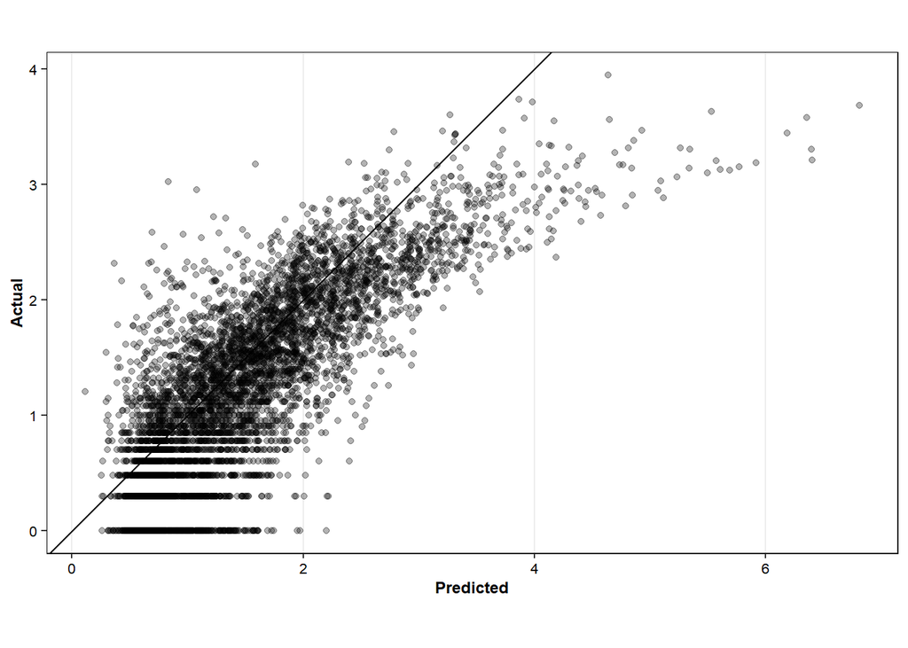

```r
tibble(Predicted = predict(lm_fit, new_data = ratings_train)[[1]] + dummies, Actual = ratings_train$reviews_from_users) %>%
  ggplot(aes(x = Predicted, y = Actual)) +
  geom_jitter(alpha = .3) +
  geom_abline() +
  coord_fixed()
```

I decide to try transforming year with a spline function toa ccount for the non-constant slope.

```r
lm_rec <-
  recipe(
    reviews_from_users ~ year + language +
      worlwide_gross_income + reviews_from_critics, data = ratings_train
  ) %>%
  step_log(worlwide_gross_income, base = 10) %>%
  step_ns(year, deg_free = tune("year_df"))

params <- lm_rec    %>%
  parameters() %>%
  update(`year_df` = spline_degree())
```

I K-fold the training data and create a training grid.

```r
splits <- vfold_cv(ratings_train)

tuning_grid <- grid_max_entropy(params, size = 10)

lm_mod <- linear_reg() %>% set_engine("lm")
```

Different degrees of freedom don’t make much difference. I decide to settle on 4.

```r
tuned <- tune_grid(lm_mod, lm_rec, resamples = splits, grid = tuning_grid )

tuned %>% collect_metrics()
```

```
# A tibble: 18 x 7
   year_df .metric .estimator  mean     n std_err .config
     <int> <chr>   <chr>      <dbl> <int>   <dbl> <chr>
 1       5 rmse    standard   0.445    10 0.00572 Preprocessor1_Model1
 2       5 rsq     standard   0.694    10 0.00933 Preprocessor1_Model1
 3       7 rmse    standard   0.443    10 0.00579 Preprocessor2_Model1
 4       7 rsq     standard   0.697    10 0.00928 Preprocessor2_Model1
 5       2 rmse    standard   0.460    10 0.00628 Preprocessor3_Model1
 6       2 rsq     standard   0.674    10 0.0104  Preprocessor3_Model1
 7       4 rmse    standard   0.448    10 0.00534 Preprocessor4_Model1
 8       4 rsq     standard   0.691    10 0.00900 Preprocessor4_Model1
 9       9 rmse    standard   0.444    10 0.00576 Preprocessor5_Model1
10       9 rsq     standard   0.696    10 0.00926 Preprocessor5_Model1
11       6 rmse    standard   0.443    10 0.00577 Preprocessor6_Model1
12       6 rsq     standard   0.696    10 0.00925 Preprocessor6_Model1
13       1 rmse    standard   0.460    10 0.00631 Preprocessor7_Model1
14       1 rsq     standard   0.674    10 0.0105  Preprocessor7_Model1
15       3 rmse    standard   0.452    10 0.00564 Preprocessor8_Model1
16       3 rsq     standard   0.684    10 0.00937 Preprocessor8_Model1
17      10 rmse    standard   0.444    10 0.00577 Preprocessor9_Model1
18      10 rsq     standard   0.696    10 0.00927 Preprocessor9_Model1
```

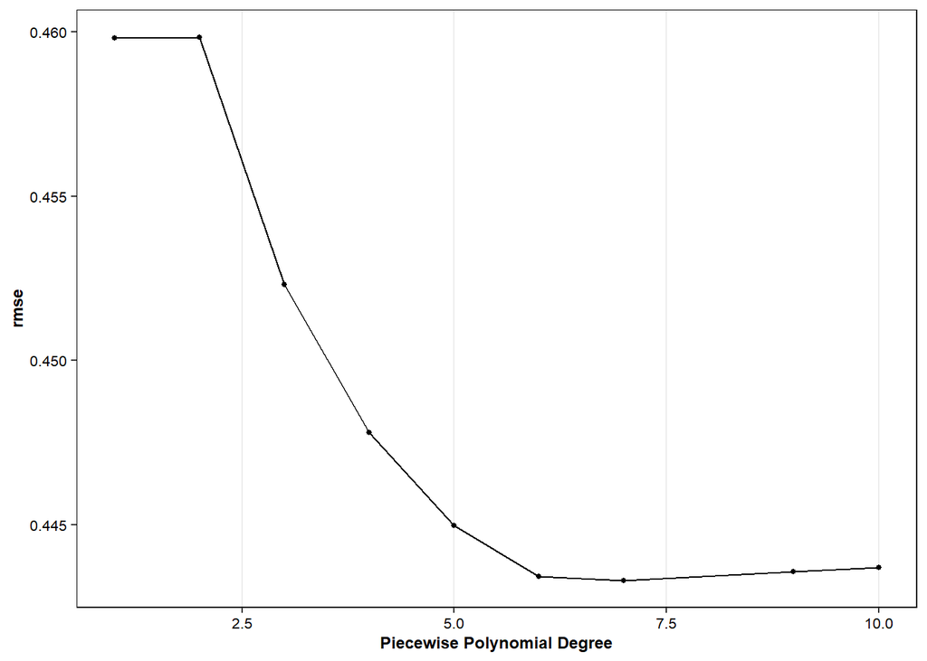

```r
autoplot(tuned, metric = "rmse")
```

I fit the updated model.

```r
lm_rec <-
  recipe(
    reviews_from_users ~ year  + language +
      worlwide_gross_income + reviews_from_critics, data = ratings_train
  ) %>%
  step_log(worlwide_gross_income, base = 10) %>%
  step_ns(year, deg_free = 4)

lm_wflow <- workflow() %>%
  add_model(linear_reg() %>% set_engine("lm")) %>%
  add_recipe(lm_rec)

lm_fit2 <- fit(lm_wflow, ratings_train)
```

The pattern remains about the same.

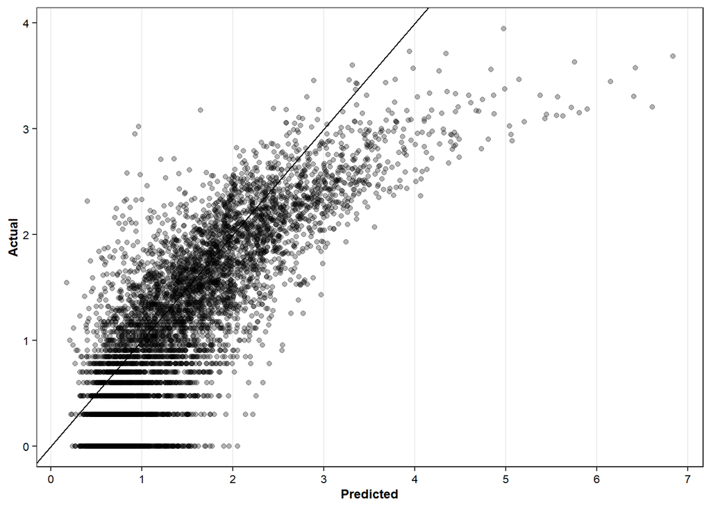

```r
tibble(Predicted = predict(lm_fit2, new_data = ratings_train)[[1]] + dummies, Actual = ratings_train$reviews_from_users) %>%
  ggplot(aes(x = Predicted, y = Actual)) +
  geom_jitter(alpha = .3) +
  geom_abline() +
  scale_x_continuous(breaks = 0:10) +
  scale_y_continuous(breaks = 0:10)
```

Our RMSE (converting back from log-10 units) is about .44, which isn’t too bad. I drop the genre-sepcific means, because they considerably worsen the RMSE.

```r
mets <- metric_set(rmse, rsq)
mets(predict(lm_fit2, new_data = ratings_train), truth = ratings_train$reviews_from_users, estimate = .pred + dummies )
```

```
# A tibble: 2 x 3
  .metric .estimator .estimate
  <chr>   <chr>          <dbl>
1 rmse    standard       0.567
2 rsq     standard       0.653
```

```r
mets(predict(lm_fit2, new_data = ratings_train), truth = ratings_train$reviews_from_users, estimate = .pred)
```

```
# A tibble: 2 x 3
  .metric .estimator .estimate
  <chr>   <chr>          <dbl>
1 rmse    standard       0.447
2 rsq     standard       0.691
```

Remarkably, RMSE is almost the same after fitting on the test set.

```r
mets(predict(lm_fit2, new_data = ratings_test), truth = ratings_test$reviews_from_users, estimate = .pred)
```

```
# A tibble: 2 x 3
  .metric .estimator .estimate
  <chr>   <chr>          <dbl>
1 rmse    standard       0.447
2 rsq     standard       0.685
```

An overview of the model. It seems most of the effect comes from language.

```r
tidy(lm_fit2)
```

```
# A tibble: 8 x 5
  term                  estimate std.error statistic  p.value
  <chr>                    <dbl>     <dbl>     <dbl>    <dbl>
1 (Intercept)            1.38    0.0964        14.3  2.10e-45
2 languageOther         -0.566   0.0137       -41.3  0.
3 worlwide_gross_income  0.107   0.00535       20.0  4.59e-86
4 reviews_from_critics   0.00440 0.0000836     52.6  0.
5 year_ns_1             -0.685   0.0929        -7.38 1.84e-13
6 year_ns_2             -1.01    0.0685       -14.8  1.25e-48
7 year_ns_3             -0.888   0.210         -4.22 2.49e- 5
8 year_ns_4             -0.268   0.0397        -6.75 1.61e-11
```